# Trevor’s Dice Problem

Gwendolin Lüdtke, Sina Spors

13 November 2018

*Tsunami scientist Trevor rolls some dice and tells you that the added result is 17. How many dice did Trevor roll?*

The problem stated above deals with the issue of likelihood. To solve the problem of Trevor, a simulation of rolling a varying number of dice should be carried out.

We can solve Trevor’s dice problem in several ways. Here you can see a possible approach:

## Creating New Variables

First of all, in order to create a more flexible code, variables are declared and initialized for the minimum and maximum number of dice, the given sum of a dice roll as well as for the number of experiments. The number of the experiments should be set to a high value to ensure a high reliability. Moreover, a vector of the length `n` containing only `NA` values is created by using the `rep` function. In the following, this vector serves as a storage location for the calculated values (number of dice rolling so that the added result is 17). The size of the vector is set to `n` to provide enough entries and the vector is filled with NA’s to not falsify the final results.

```r
min_dice <- 3 #Minimum number of dice for rolling the specified sum
max_dice <- 17 #Maximum number of dice for rolling the specified sum
total_value <- 17 #Specified sum of a dice roll
n <- 100000 #Number of experiments
x <- rep(NA,n) #Vector for storing calculated values
```

## Using Loops for the Simulation

After the declaration and initialization of the variables, nested `for-loops` are used to simulate the repetition of throwing 3 to 17 dice a certain number of times. The first loop will be repeated `n`-times to ensure a high number of experiments. The second, nested loop runs, for our example, from `i = 3` to `i = 17`. Running through the loop, throwing of `i` dice is simulated. Within this loop, the `sample` function creates randomly values between 1 and 6 with a varying number of dice. This simulates rolling `i` six-sided dice. Due to the setting `replace=TRUE` the throwing of the dice is with replacement so that more than six dice can be used. It should be noted that the number of eyes on the dice must be added together for answering the question above. This can be achieved by the `sum` function that calculates the sum.

```r
#Repeat this lopp n-times
for (y in 1:n) {

  #Loop for the number of dice i
  for (i in min_dice:max_dice) {

       s <- sum(sample(1:6,i, replace = T)) #Calculate the sum of the dice roll

       if (s == total_value){ #Write the number of dice in vector x if the sum of the dice roll equals to 17
          x[i+y] <- i
        }
    }
}
```

## Creating a Plot

For the illustration of the results, a histogram can be created by using `hist`. By defining the axis boundaries, a precise view of the concrete value range of the experiment can be created.

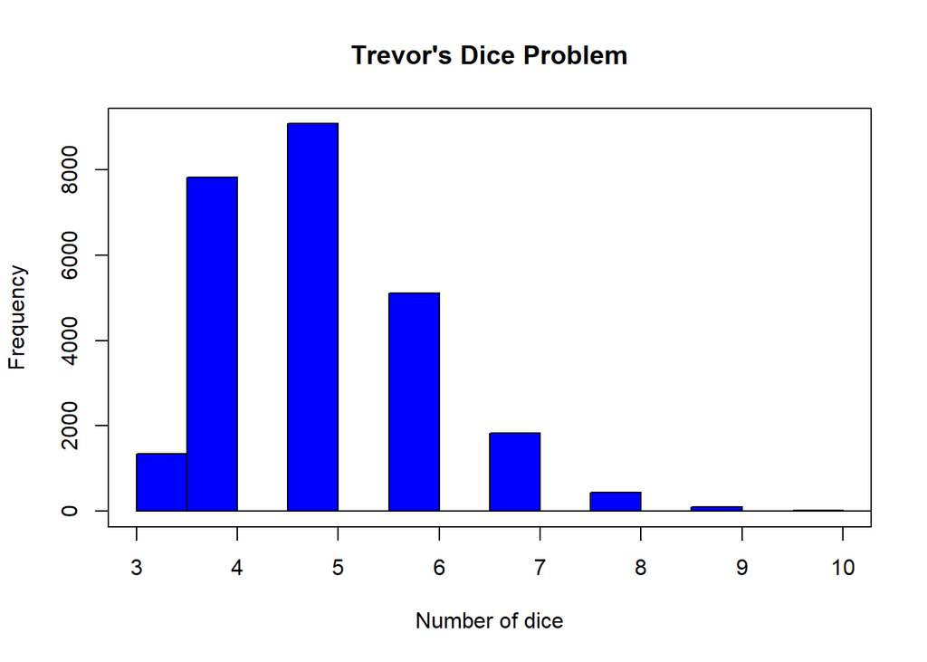

```r
hist(x,
     main = "Trevor's Dice Problem",
     xlab = "Number of dice",
     ylab = "Frequency",
     col  = "blue",
     xlim = c(3,10),
     freq = TRUE) #Frequencies are plotted

box()
```

The histogram could also be a representation of probability densities instead of frequencies. If `freq = FALSE`, probability densities are plotted. So you can see how likely it is that an interval of values of the x-axis occurs. The histogram shows that it is most likely to roll a 17 when using 5 dice. With 6 or more dice it is noticeable that it is increasingly unlikely to roll a 17.

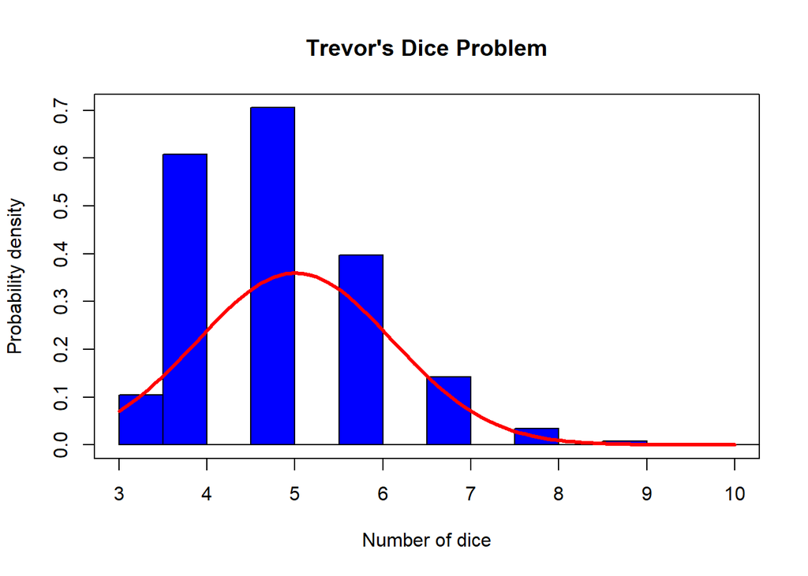

```r
hist(x,
     main = "Trevor's Dice Problem",
     xlab = "Number of dice",
     ylab = "Probability density",
     col  = "blue",
     xlim = c(3,10),
     freq = FALSE) #Probability densities are plotted

#Plot density function over the histogram (normal distribution)
m <- mean(x, na.rm = TRUE) #na.rm = TRUE: NA values should be stripped before the computation proceeds
sd <-  sd(x, na.rm = TRUE)
curve(dnorm(x,m,sd),add=TRUE,lwd=3, col = "red")

box()
```